# Principal components analysis

Reference: Introduction to Statistical Learning Chapter 10.1-10.2

### Outline

1. Introduction to PCA
2. Brief reminder of some linear algebra notation
3. PCA as a projection
4. PCA as a regression on latent variables

### Introduction to PCA

The goal of PCA is to find low-dimensional summaries of high-dimensional data sets.

This is useful for compression, for denoising, for plotting, and for making sense of data sets that initially seem too complicated to understand.

It differs from clustering:

- Clustering assumes that each data point is a member of one, and only one, cluster. (Clusters are mutually exclusive.)
- PCA assumes that each data point is like a combination of multiple basic “ingredients.” (Ingredients are not mutually exclusive.)

### Think about recipes:

Nestle Toll House Chocolate-chip cookies: 280 grams flour, 150 grams white sugar, 165 grams brown sugar, 225 grams butter, 2 eggs, 0 grams water…

Mary Berry's Victoria sponge cake: 225 grams flour, 225 grams white sugar, 0 grams brown sugar, 225 grams butter, 4 eggs, 0 grams water…

seriouseats.com [old fashioned flaky pie dough](https://www.seriouseats.com/recipes/2016/06/old-fashioned-flaky-pie-dough-recipe.html): 225 grams flour, 15 grams white sugar, 0 grams brown sugar, 225 grams butter, 0 eggs, 115 grams water…

### Think about recipes:

Each baked good is constructed by following a recipe: a combination of the same basic ingredients.

- Each data point \( x_i \) is like a baked good.
- In PCA, the **principal components** are like the ingredients.

The amounts of each ingredient differ from one baked good to the next:

- E.g. 225g sugar for sponge cake versus 15 grams sugar for pie dough.
- In PCA, the **scores** are like the amounts of each ingredient in a given baked good.

### Think about recipes:

Our goal is to reverse-engineer both the **ingredients** and the **amounts/recipes** from an observed set of “baked goods” (i.e. original data points).

### Some linear algebra reminders

Alas, PCA is less delicious than baking, and it uses more linear algebra. Say that \( v \in \mathbb{R}^P \) is some vector. This defines a *subspace* of \( \mathbb{R}^P \): \[ \mathcal{V} = \left\{z: z = \alpha_i v, \alpha_i \in \mathbb{R} \right\} \]

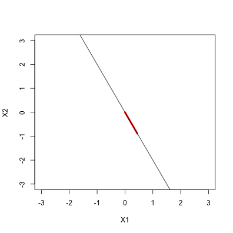

### Some linear algebra reminders

Now let \( X \) be our usual \( N \times P \) data matrix with rows \( x_i^T \).

Suppose we *project* each \( x_i^T \) in our data matrix onto the subspace \( \mathcal{V} \).

- The scalar location along the vector \( v \) is \[ \alpha_i = x_i \cdot v = x_i^T v \]
- The location of the projected point in \( \mathcal{R}^P \) is \[ \hat{x_i} = \alpha_i v = (x_i \cdot v) v \]

### The original points

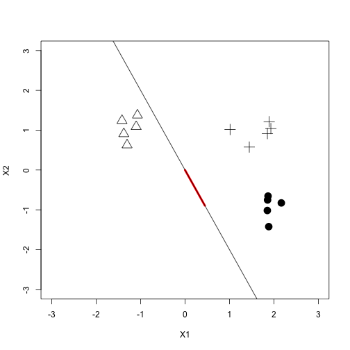

### With the projected points

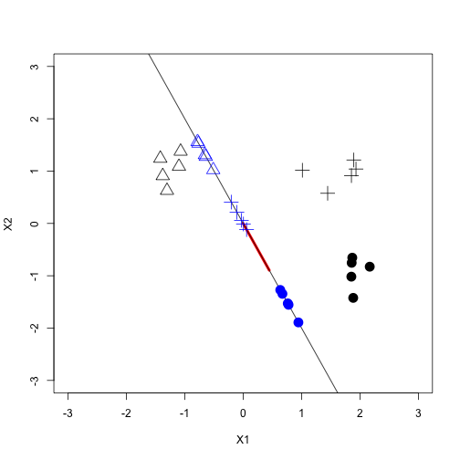

### Key ideas

Key idea 1: projection = summary

- Each point's location along the subspace is a **one-number linear summary** of a \( P \)-dimensional data vector: \[ \alpha_i = x_i \cdot v = x_i^T v \]
- The goal of principal components analysis (PCA) is to find the “best” projection, i.e. the best linear summary of the data points.

Key idea 2: the “best summary” is the one that preserves as much of the **variance** in the original data points as possible.

Let's walk through `pca_intro.R`

### PCA as an optimization problem

Given data points \( x_1, \ldots, x_N \), with each \( x_i \in \mathbb{R}^{P} \), and a candidate vector \( v_1 \), the variance of the projected points is \[ \mathrm{variance} = \frac{1}{n} \sum_{i=1}^n \left[ \alpha_i - \bar{\alpha} \right]^2 \] where \( \alpha_i x_i \cdot v_1 \).

So we solve: \[ \underset{v_1 \in \mathbb{R}\, , \; \Vert v \Vert_2 = 1}{\mathrm{maximize}} \quad \sum_{i=1}^n \left[x_i \cdot v_1 - \left( \frac{1}{n} \sum_{i=1}^N x_i \cdot v_1 \right) \right]^2 \]

Note: we constrain \( v_1 \) to have length 1; otherwise we could blow up the variance of the projected points as large as we wanted to.

### PCA as an optimization problem

The solution \( v_1 \) to this optimization problem:

- is called the first principal component (synonyms: loading, rotation.)
- is the one-dimensional subspace capturing as much of the information in the original data matrix as possible.

The projected points \( \alpha_i = x_i \cdot v \) are called the *scores* on the first principal component.

### PCA as regression on latent variables

We can think of the projected location of \( x_i \) as an approximation to the original data point: \( x_i \approx \hat{x}_i = \alpha_i v \).

Or to make the approximation error explicit: \[ \begin{aligned} x_{ij} &= \hat{x}_{ij} + e_i \\ &= \alpha_i v_{j} + e_i \end{aligned} \] This is like a regression problem for the jth feature variable.

- The \( \alpha_i \)'s are like hidden (latent) features.
- \( v_j \) is like a regression coefficient for observed variable \( j \).

Thus PCA is like estimating \( P \) regression coefficients \( v_1 = (v_{11}, \ldots, v_{1P}) \) all at once, where the feature variable is hidden.

### PCA as regression on latent variables

We can write the approximation for the whole matrix as follows:

\[ \begin{aligned} X &\approx \left( \begin{array}{r r r r} \alpha_1 v_{11} & \alpha_1 v_{12} & \cdots & \alpha_1 v_{1P} \\ \alpha_2 v_{11} & \alpha_2 v_{12} & \cdots & \alpha_2 v_{1P} \\ \vdots & \vdots & & \vdots \\ \alpha_N v_{11} & \alpha_N v_{12} & \cdots & \alpha_N v_{1P} \\ \end{array} \right) \\ &= \alpha v_1^T \quad \mbox{(outer product of $\alpha$ and $v_1$)} \end{aligned} \]

### PCA as regression on latent variables

And if we explicitly include the error term:

\[ X = \alpha v_1^T + E \]

where \( E \) is a residual matrix with entries

\[ \begin{aligned} E_{ij} &= x_{ij} - \hat{x}_{ij} \\ &= x_{ij} - \alpha_i v_{1j} \end{aligned} \]

### Higher-order principal components

With this in place, we can now define principal components 2 and up!

- PC 2: run PCA on the residual matrix from PC 1.
- PC 3: run PCA on the residual matrix from PCs 1-2.
- \( \cdots \)
- PC P: run PCA on the residual matrix from PCs 1-(P-1).

Thus principal component \( M \) is defined recursively in terms of the fit from principal components 1 through \( M-1 \).

### Higher-order principal components

Note: in practice we often stop with far fewer than \( P \) principal components.

Let's see the examples in `congress109.R` and `NCI60.R`.